# P2：探索数据集

# 关于泰坦尼克号数据的开放式提问：

```
1：游客购买船票的类型与生还率的关系
2：游客的性别与生还率的关系
3：游客的年龄与生还率的关系
4：游客登船的港口与生还率的关系
5：游客是否有独立的船舱与生还率的关系
6：游客同船的兄弟姐妹人数\父母孩子人数与生还率的关系
```

泰坦尼克号数据的数据字典（中文版）解析：

数据来源：https://www.kaggle.com/c/titanic/data

PassengerId：游客编号

Survived：幸存情况

Pclass：船票类型

1：表示（头等舱） 2：表示（二等舱） 3：表示（三等舱）

Name：姓名

Sex：性别

Age：年龄

SibSp：与游客本人一同在船上的兄弟姐妹或者配偶

Parch：与游客本人一同在船上的父母或者孩子

Ticket：船票号码

Fare：船票价格

Cabin：船舱编号

Embarked：登船港口

关键变量解析：

Pclass:代表了社会经济地位。 1：代表（上层） 2：代表（中层） 3：代表（底层）

# 泰坦尼克号数据分析的主程序以及相关分析推论：

函数库的导入，以及数据的导入部分：

```python
import pandas as pd
import seaborn as sns
import matplotlib.pyplot as plt
import numpy as np
%matplotlib inline
%pylab inline
titanic_data_df = pd.read_csv('titanic-data.csv')
```

对 titanic_data_df 数据进行初步数据观察：

```python
titanic_data_df.head()#概览数据框DataFrame前五行的内容。
```

|  | PassengerId | Survived | Pclass | Name | Sex | Age | SibSp | Parch | Ticket | Fare | Cabin | Embarked |
| --- | --- | --- | --- | --- | --- | --- | --- | --- | --- | --- | --- | --- |
| 0 | 1 | 0 | 3 | Braund, Mr. Owen Harris | male | 22.0 | 1 | 0 | A/5 21171 | 7.2500 | NaN | S |
| 1 | 2 | 1 | 1 | Cumings, Mrs. John Bradley (Florence Briggs Th... | female | 38.0 | 1 | 0 | PC 17599 | 71.2833 | C85 | C |
| 2 | 3 | 1 | 3 | Heikkinen, Miss. Laina | female | 26.0 | 0 | 0 | STON/O2. 3101282 | 7.9250 | NaN | S |
| 3 | 4 | 1 | 1 | Futrelle, Mrs. Jacques Heath (Lily May Peel) | female | 35.0 | 1 | 0 | 113803 | 53.1000 | C123 | S |
| 4 | 5 | 0 | 3 | Allen, Mr. William Henry | male | 35.0 | 0 | 0 | 373450 | 8.0500 | NaN | S |

查看 titanic_data_df 数据框的整体信息，观察哪些列中含有缺失值。

```python
titanic_data_df.info()
```

```
<class 'pandas.core.frame.DataFrame'>
RangeIndex: 891 entries, 0 to 890
Data columns (total 12 columns):
PassengerId    891 non-null int64
Survived       891 non-null int64
Pclass         891 non-null int64
Name           891 non-null object
Sex            891 non-null object
Age            714 non-null float64
SibSp          891 non-null int64
Parch          891 non-null int64
Ticket         891 non-null object
Fare           891 non-null float64
Cabin          204 non-null object
Embarked       889 non-null object
dtypes: float64(2), int64(5), object(5)
memory usage: 83.6+ KB
```

通过观察 titanic_data_df 数据框的整体信息，可知：

索引RangeIndex: 891，Age：714，Cabin：204，Embarked：889。因此：数据框中含有缺失值的列是'Age'、'Cabin'、'Embarked'

为了不影响数据分析的准确性，这里选择在分析具体列时，再删除缺失值所在行或者变更缺失值，而不是在最开始就进行全部的数据清洗和变更。

# 1.0：购买不同等级船票的游客人口分布。

```python
Pclass_count = titanic_data_df.groupby('Pclass',as_index = False)['PassengerId'].count()
print Pclass_count['PassengerId'].sum()#总人数
Pclass_count#打印出购买不同等级船票的游客人口分布
```

```
891
```

|  | Pclass | PassengerId |
| --- | --- | --- |
| 0 | 1 | 216 |
| 1 | 2 | 184 |
| 2 | 3 | 491 |

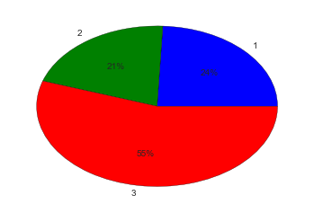

```python
plt.pie(Pclass_count['PassengerId'],labels = Pclass_count['Pclass'],autopct = '%.0f%%')#画出购买不同等级船票的游客人口分布的饼状图。
```

1.0小结：船上一共有891人，其中有有491人购买了三等舱船票，有184人购买了二等舱船票，有216人购买了一等舱船票。从饼状图可以看出，有55%的游客购买了三等舱船票，有21%的游客购买了二等舱船票，有24%的游客购买了一等舱的船票。购买三等舱船票的人数占船上总人数的一半以上。

# 1.1：游客购买船票的等级与生还率的关系

数据说明（摘要）：Pclass是船票的类型；1：代表（头等舱）2：代表（二等舱）3：代表（三等舱）

```
              Pclass还是船上游客的社会经济地位和身份的象征；1：代表（上流社会）2：代表（中产阶级）3：代表（底层人民）
```

数据来源：https://www.kaggle.com/c/titanic/data

```python
Pclass_Survived_mean = titanic_data_df.groupby('Pclass')['Survived'].mean()
Pclass_Passengers_count = titanic_data_df.groupby('Pclass')['Survived'].count()
Pclass_Survived_mean#依次显示购买头等舱船票到购买三等舱船票的游客的生存概率。
```

```
Pclass
1    0.629630
2    0.472826
3    0.242363
Name: Survived, dtype: float64
```

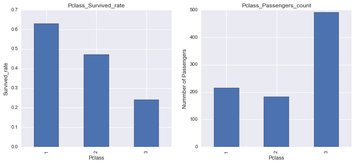

```python
plt.figure(figsize=(12,5))
f,(ax1,ax2) = plt.subplots(1,2)
f.set_size_inches(12,5)
Pclass_Survived_mean.plot(kind = 'bar',ax = ax1)#画出每类船票所对应的游客生还率柱状图。
Pclass_Passengers_count.plot(kind = 'bar',ax = ax2)#画出每类船票所对应的购买人数。
ax1.set_title('Pclass_Survived_rate')
ax1.set_ylabel('Survived_rate')
ax2.set_title('Pclass_Passengers_count')
ax2.set_ylabel('Nummber of Passengers')
```

1.1小结：从柱状图可以看出，头等舱的游客生存概率最高，二等舱的生存概率次之，三等舱的游客生存概率最低。

# 1.2：游客购买船票的等级与生还率的相关性验证

```python
def correlation(x,y): #计算两组数据相关性的函数。
    std_x = (x - x.mean())/ x.std(ddof = 0)
    std_y = (y - y.mean())/ y.std(ddof = 0)
    return (std_x * std_y).mean()#皮尔逊积矩相关系数
```

```python
Pclass = Pclass_Survived_mean.index.values#把生还率的索引值找出来然后转变成数组，也就是生还率对应的船票等级
Survived = Pclass_Survived_mean.values#把生还率转换成数组
print '船票类型:',Pclass,'\n'
print '船票类型对应生还率:',Survived,'\n'
print '皮尔逊积矩（相关系数）:',correlation(Pclass,Survived)#求出船票类型与生还率之间的相关性
```

```
船票类型: [1 2 3]

船票类型对应生还率: [ 0.62962963  0.47282609  0.24236253]

皮尔逊积矩（相关系数）: -0.994024355227
```

1.2小结：通过相关性函数计算出，皮尔逊积矩相关系数约等于-0.99非常接近-1。通常情况下当系数接近1或者接近-1的情况下，我们会认为两组数据具有高度相关性。而本次计算结果非常接近-1，说明随着船票等级下降，游客的生还率也会随之大幅下降。虽然本次相关性的计算，每组数据的数据量只有3个，但是每组数据的统计计算都来自于船上的几乎所有乘客，因此此次相关性的验证计算是可靠而且有说服力的。

1推论二：由于在数据来源的关键变量描述中，我们看到船票等级还是社会身份地位的象征，因此高等级船舱的游客生还率更高，不排除有在逃生和救援时由于身份地位不平等导致的救援顺序的差异因素。也就是说高等级船舱，除了有更好的救生设备，和更容易拿到的救生设备以外，逃生和救援的优先级别也许也是导致高等级船舱游客生还率高的原因。

# 2.0：游客性别的人口分布

```python
Sex_count = titanic_data_df.groupby('Sex',as_index = False)['PassengerId'].count()
print Sex_count['PassengerId'].sum()#显示游客的总人数。
Sex_count#打印出船上游客性别的人口分布
```

```
891
```

|  | Sex | PassengerId |
| --- | --- | --- |
| 0 | female | 314 |
| 1 | male | 577 |

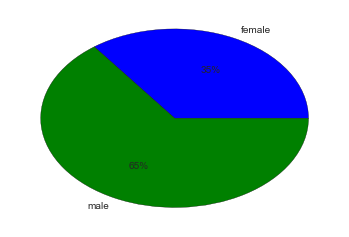

```python
plt.pie(Sex_count['PassengerId'],labels = Sex_count['Sex'],autopct = '%.0f%%')#画出船上不同性别的人口分布饼状图。
```

# 2.1：游客的性别与生还率的关系

```
Sex
female    0.742038
male      0.188908
Name: Survived, dtype: float64
```

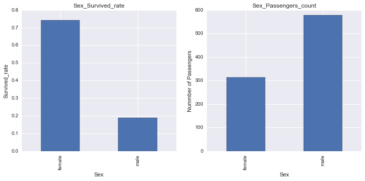

```python
Sex_Survived_mean = titanic_data_df.groupby('Sex')['Survived'].mean()
Sex_Passengers_count = titanic_data_df.groupby('Sex')['Survived'].count()
print Sex_Survived_mean#打印出不同性别游客的生还率
f,(ax1,ax2) = plt.subplots(1,2)
f.set_size_inches(12,5)
Sex_Survived_mean.plot(kind = 'bar',ax = ax1)#画出不同性别游客生还率的柱状图。
Sex_Passengers_count.plot(kind = 'bar',ax = ax2)#画出不同性别游客的人数。
ax1.set_title('Sex_Survived_rate')
ax1.set_ylabel('Survived_rate')
ax2.set_title('Sex_Passengers_count')
ax2.set_ylabel('Nummber of Passengers')
```

2.1小结：女性游客的生还率为74%，男性游客的生还率为19%。从柱状图可以看出，女性游客的生还率要明显高于男性游客。

2推论：根据2.0和2.1的小结可以推论，船上的游客在逃生时，普遍遵循女士优先的原则，身体强壮的男士把更多的逃生机会和逃生资源让给了相对弱势的女性群体，导致大部分的男性由于错过了最佳的逃生时机或者因为没有充足的逃生资源而遇难。

# 3.0：游客的年龄人口分布

```python
Age_Survived = titanic_data_df[['Age','Survived']].dropna()
```

缺失值处理（备注）：此处把后续需要用到的列'Age','Survived'从titanic_data_df中拿出来赋值给新的变量Age_Survived，同时去掉'Age'列的缺失值所在行。

```python
bins = [0,20,40,60,80]#把Pclass_Age_mean_df中的['Age']分组0-20,20-40,40-60,60-80
labels = ['0-20','20-40','40-60','60-80']#给被分组的元素统一添加标签。
Age_Survived['Age'] = pd.cut(Age_Survived['Age'],bins,labels)#使用pd.cut方法将Age列分为四组。
Age_Survived.head()#概览数据框DataFrame前五行的内容，查看处理好的数据是否符合要求。
```

|  | Age | Survived |
| --- | --- | --- |
| 0 | (20, 40] | 0 |
| 1 | (20, 40] | 1 |
| 2 | (20, 40] | 1 |
| 3 | (20, 40] | 1 |
| 4 | (20, 40] | 0 |

```python
Age_count = Age_Survived.groupby('Age',as_index = False)['Survived'].count()#计算每个年龄段的人口分布
Age_count#每个年龄段的人口分布统计表
```

|  | Age | Survived |
| --- | --- | --- |
| 0 | (0, 20] | 179 |
| 1 | (20, 40] | 385 |
| 2 | (40, 60] | 128 |
| 3 | (60, 80] | 22 |

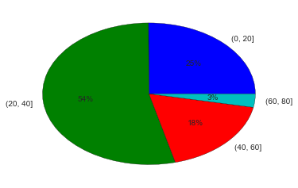

```python
plt.pie(Age_count['Survived'],labels = Age_count['Age'],autopct = '%0.0f%%')#用饼状图描述每个年龄段的人口分布。
```

3.0小结：从人口分布统计表可以得出：0-20岁的游客有179人，20-40岁的游客有385人，40-60岁的游客有128人，60-80岁的游客有22人。人口分布饼状图可以看出：0-20岁的游客占总游客的25%，20-40岁的游客占总游客的54%，40-60岁的游客占总游客的18%，60-80岁的游客占总游客的3%。

# 3.1：游客的年龄与生还率的关系

```python
Age_Survived_mean = Age_Survived.groupby('Age')['Survived'].mean()
Age_Passengers_count = Age_Survived.groupby('Age')['Survived'].count()
Age_Survived_mean#不同年龄段生还率统计表
```

```
Age
(0, 20]     0.458101
(20, 40]    0.397403
(40, 60]    0.390625
(60, 80]    0.227273
Name: Survived, dtype: float64
```

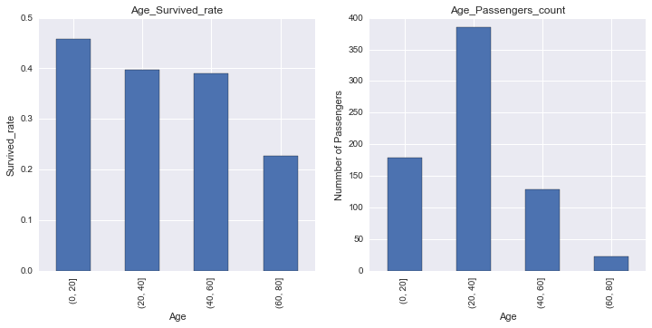

```python
f,(ax1,ax2) = plt.subplots(1,2)
f.set_size_inches(12,5)
Age_Survived_mean.plot(kind = 'bar',ax = ax1)#用柱状图画出不同年龄段的生还率
Age_Passengers_count.plot(kind = 'bar',ax = ax2)#用柱状图画出每个年龄段的人数。
ax1.set_title('Age_Survived_rate')
ax1.set_ylabel('Survived_rate')
ax2.set_title('Age_Passengers_count')
ax2.set_ylabel('Nummber of Passengers')
```

3.1小结：从柱状图可以看出，船上0-20岁的青少年生还率最高。

3推论：从小结3.0和小结3.1可以推论，船上的大部分成年人普遍遵循保护幼小的社会价值观，把更多的逃生机会和更好的逃生资源让给了20岁以下的青少年，这才导致0-20岁的青少年生还率最高。

# 4：在不同等级的船舱中，游客的性别与生还率的关系。

```python
Pclass_Sex_mean = titanic_data_df.groupby(['Pclass','Sex'])['Survived'].mean()
Pclass_Sex_count = titanic_data_df.groupby(['Pclass','Sex'])['Survived'].count()
```

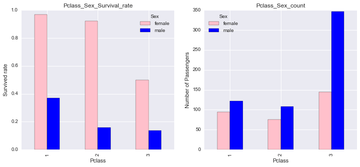

```python
plt.figure(figsize=(14,5))
p,(ax1,ax2) = plt.subplots(1,2)
p.set_size_inches(12,5)
Pclass_Sex_mean.unstack().plot(kind = 'bar',color = ['pink','blue'],ax = ax1)
ax1.set_title('Pclass_Sex_Survival_rate')
ax1.set_ylabel('Survived rate')
Pclass_Sex_count.unstack().plot(kind = 'bar',color = ['pink','blue'],ax = ax2)
ax2.set_title('Pclass_Sex_count')
ax2.set_ylabel('Number of Passengers')
```

4小结：无论在一等舱，二等舱，还是三等舱，女性的生还率都明显高于男性。同时，三等舱中女性的生还率要明显低于一等舱和二等舱中女性的生还率。

4推论：尽管船上的大部分游客都遵循了女士优先逃生的绅士原则和普世价值观，但是在不同级别的穿舱中，女性逃生的优先级别依然是不相同的，三等舱中的女性与一等舱、二等舱中的女性相比，无法拥有相同的逃生资源和平等的逃生优先级别，导致三等舱中的女性生还率要远远低于一等舱和二等舱中的女性生还率。

# 5：在不同等级的船舱中，游客的年龄与生还率的关系

```python
Pclass_Age_Sex_Survived_df = titanic_data_df[['Pclass','Age','Sex','Survived']].dropna()
```

```python
Pclass_Age_Sex_Survived_df.head()#概览数据框DataFrame前五行的内容,查看缺失值的处理情况以及新变量是否数据完整。
```

|  | Pclass | Age | Sex | Survived |
| --- | --- | --- | --- | --- |
| 0 | 3 | 22.0 | male | 0 |
| 1 | 1 | 38.0 | female | 1 |
| 2 | 3 | 26.0 | female | 1 |
| 3 | 1 | 35.0 | female | 1 |
| 4 | 3 | 35.0 | male | 0 |

```python
bins = [0,20,40,60,80]#把Pclass_Age_mean_df中的['Age']分组0-20,20-40,40-60,60-80
labels = ['0-20','20-40','40-60','60-80']#给被分组的元素统一添加标签。
Pclass_Age_Sex_Survived_df['Age'] = pd.cut(Pclass_Age_Sex_Survived_df['Age'],bins,labels)#使用pd.cut方法将Age列分为四组。
Pclass_Age_Sex_Survived_df.head()#概览数据框DataFrame前五行的内容，查看处理好的数据是否符合要求。
```

|  | Pclass | Age | Sex | Survived |
| --- | --- | --- | --- | --- |
| 0 | 3 | (20, 40] | male | 0 |
| 1 | 1 | (20, 40] | female | 1 |
| 2 | 3 | (20, 40] | female | 1 |
| 3 | 1 | (20, 40] | female | 1 |
| 4 | 3 | (20, 40] | male | 0 |

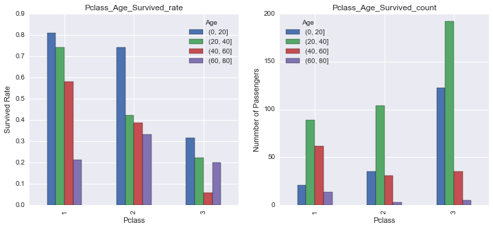

```python
Pclass_Age_Survived_df_mean = Pclass_Age_Sex_Survived_df.groupby(['Pclass','Age'])['Survived'].mean()#用groupby()分组。
Pclass_Age_Survived_df_count = Pclass_Age_Sex_Survived_df.groupby(['Pclass','Age'])['Survived'].count()#用groupby()分组。
f,(ax1,ax2) = plt.subplots(1,2)#设置子图数量，和传递子徒参数。
f.set_size_inches(12,5)#设置图像大小
Pclass_Age_Survived_df_mean.unstack().plot(kind = 'bar',ax = ax1)#把船票等级和年龄分开显示，X轴为船票等级，颜色代表年龄，Y轴为生还率，
ax1.set_title('Pclass_Age_Survived_rate')#给子图1添加标题
ax1.set_ylabel('Survived Rate')#给子图1添加y轴标签
Pclass_Age_Survived_df_count.unstack().plot(kind = 'bar',ax = ax2)#把船票等级和年龄分开显示，X轴为船票等级，颜色代表年龄，Y轴为生还人数。
ax2.set_title('Pclass_Age_Survived_count')#给子图2添加标题
ax2.set_ylabel('Nummber of Passengers')#给子图2添加y轴标签
```

5小结：无论在一等舱、二等舱、还是三等舱，0-20岁游客的生还率，都明显高于其他年龄段游客的生还率。但同时，三等舱中0-20岁游客的生还率要远远低于一等舱和二等舱0-20岁游客的生还率。

5推论：虽然，船上的游客普遍遵循青少年优先逃生的价值观，但是由于船舱等级的限制，三等舱青少年的逃生率要远远低于一等舱和二等舱，说明年龄的优势依然无法跨越船舱等级带来的逃生限制。也就是说，即便是三等舱的小孩儿和青少年，也不能和一等舱和二等舱的小孩一样拥有相同的优先逃生资源与平等的逃生机会。不同的船舱等级是造成0-20岁青少年生还率差异的主要因素。

# 6.1：在不同性别的游客中，游客的年龄与生还率的关系（柱状图分析）

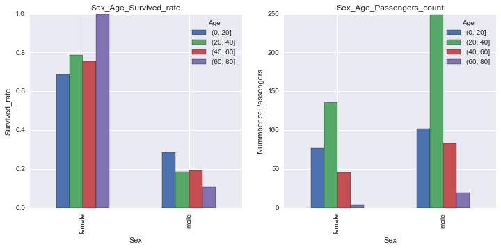

```python
Sex_Age_Survived_mean = Pclass_Age_Sex_Survived_df.groupby(['Sex','Age'])['Survived'].mean()
Sex_Age_Survived_count = Pclass_Age_Sex_Survived_df.groupby(['Sex','Age'])['Survived'].count()
f,(ax1,ax2) = plt.subplots(1,2)
f.set_size_inches(12,5)
Sex_Age_Survived_mean.unstack().plot(kind = 'bar',ax = ax1)
Sex_Age_Survived_count.unstack().plot(kind = 'bar',ax =ax2)
ax1.set_title('Sex_Age_Survived_rate')
ax1.set_ylabel('Survived_rate')
ax2.set_title('Sex_Age_Passengers_count')
ax2.set_ylabel('Nummber of Passengers')
```

# 6.2：在不同性别的游客中，游客的年龄与生还率的关系（散点图分析）

```python
titanic_data_df['Sex'].replace(['male','female'],[1,0],inplace=True)
```

数据变更（备注）：上一行代码是数据变更，从这里开始把系统中 titanic_data_df 数据框中['Sex']这列的male和female元素替换成1和0

```python
titanic_data_df.head()#概览数据框DataFrame前五行的内容,查看数据变更后[Sex]列的情况
```

|  | PassengerId | Survived | Pclass | Name | Sex | Age | SibSp | Parch | Ticket | Fare | Cabin | Embarked |
| --- | --- | --- | --- | --- | --- | --- | --- | --- | --- | --- | --- | --- |
| 0 | 1 | 0 | 3 | Braund, Mr. Owen Harris | 1 | 22.0 | 1 | 0 | A/5 21171 | 7.2500 | NaN | S |
| 1 | 2 | 1 | 1 | Cumings, Mrs. John Bradley (Florence Briggs Th... | 0 | 38.0 | 1 | 0 | PC 17599 | 71.2833 | C85 | C |
| 2 | 3 | 1 | 3 | Heikkinen, Miss. Laina | 0 | 26.0 | 0 | 0 | STON/O2. 3101282 | 7.9250 | NaN | S |
| 3 | 4 | 1 | 1 | Futrelle, Mrs. Jacques Heath (Lily May Peel) | 0 | 35.0 | 1 | 0 | 113803 | 53.1000 | C123 | S |
| 4 | 5 | 0 | 3 | Allen, Mr. William Henry | 1 | 35.0 | 0 | 0 | 373450 | 8.0500 | NaN | S |

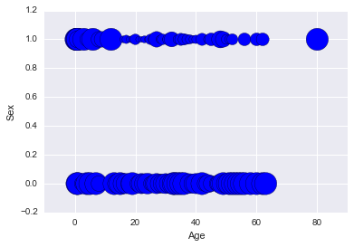

```python
Sex_Age_Survived = titanic_data_df.groupby(['Sex','Age'],as_index = False)['Survived'].mean()#计算具有相同性别和年龄的游客的生还率。
print plt.scatter(Sex_Age_Survived['Age'],Sex_Age_Survived['Sex'],s = Sex_Age_Survived['Survived']*600)#画出散点图，气泡的大小是生还率的800倍。
plt.xlabel('Age')#X轴标签
plt.ylabel('Sex')#Y轴标签
```

5小结：从散点图可以看出：

```
1：随着年龄的增长，每个年龄段的女性的生还率基本没有变化，一直保持着较高的生还生还率。
2：18岁以下的男性生还率基本和女性的平均生还率保持一致，18岁-62岁的男性生还率要远远低于女性的平均生还率。
3: 除了一位80岁的男性老人以外，63岁以上的老人没有一个生还。
```

推论2：如果第一个推论成立，那么可以增加生还率的方式是：游轮有足够的救生物资可在危机的时刻使用，而且要放在容易拿到的地方，不会因为物资不足或者因为难以拿到救生物资而导致原本有自救能力的大多数男性游客失去宝贵的生还机会。

推论3: 除了一位80岁的男性老人以外，63岁以上的老人没有一个生还的原因，因该是超过63岁的老人体力跟不上，即便年轻人把救生设备及时给了这些高领老人，他们也没有体力自救，在被救或者等待救援的过程中因为体力不足而遇难。

# 7.0:游客登船港口的人口分布

```python
Embarked_Survived_Pclass_df = titanic_data_df[['Embarked','Survived','Pclass']].dropna()
```

```python
Embarked_Survived_count = Embarked_Survived_Pclass_df.groupby('Embarked',as_index = False)['Survived'].count()
Embarked_Survived_count#从不同港口登船的游客人口分布
```

|  | Embarked | Survived |
| --- | --- | --- |
| 0 | C | 168 |
| 1 | Q | 77 |
| 2 | S | 644 |

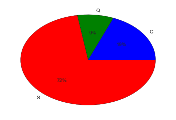

```python
plt.pie(Embarked_Survived_count['Survived'] ,labels = Embarked_Survived_count['Embarked'],autopct = '%0.0f%%')#画出饼状图
```

7.0小结：从不同港口登船游客人口分布统计表可知，从C港口登船的游客人数是168人，从Q港口登船的游客人数是77人，从S港口登船的游客人数是644人。从S港口登船的游客人数最多。从饼状图可以看出，从S港口登船的游客占总游客人数的72%。

# 7.1：游客登船的港口与生还率的关系

```python
Embarked_Survived_mean = Embarked_Survived_Pclass_df.groupby('Embarked')['Survived'].mean()
Embarked_Passengers_count = Embarked_Survived_Pclass_df.groupby('Embarked')['Survived'].mean()
Embarked_Survived_mean# 分别从C、Q、S、三个港口登船的游客的生还率。
```

```
Embarked
C    0.553571
Q    0.389610
S    0.336957
Name: Survived, dtype: float64
```

[figure not shown]

```python
f,(ax1,ax2) = plt.subplots(1,2)
f.set_size_inches(12,5)
Embarked_Survived_mean.plot(kind = 'bar',ax = ax1)
Embarked_Passengers_count.plot(kind = 'bar',ax = ax2)
ax1.set_title('Embarked_Survived_rate')
ax1.set_ylabel('Survived_rate')
ax2.set_title('Embarked_Passengers_count')
ax2.set_ylabel('Nummber of Passengers')
```

7.1小结：从柱状图可以看出，C港口登船的游客生还概率最高，S港口登船的游客生概率最低。

# 7.2：游客购买船票的等级、登船港口与生还率的关系。

```python
Pclass_Embarked_Survived_mean = Embarked_Survived_Pclass_df.groupby(['Pclass','Embarked'])['Survived'].mean()
Pclass_Embarked_Survived_count = Embarked_Survived_Pclass_df.groupby(['Pclass','Embarked'])['Survived'].count()
Pclass_Embarked_Survived_mean
```

```
Pclass  Embarked
1       C           0.694118
        Q           0.500000
        S           0.582677
2       C           0.529412
        Q           0.666667
        S           0.463415
3       C           0.378788
        Q           0.375000
        S           0.189802
Name: Survived, dtype: float64
```

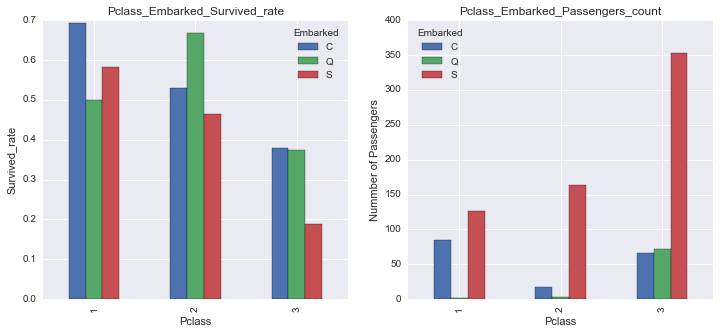

```python
f,(ax1,ax2) = plt.subplots(1,2)
f.set_size_inches(12,5)
Pclass_Embarked_Survived_mean.unstack().plot(kind = 'bar',ax = ax1)
Pclass_Embarked_Survived_count.unstack().plot(kind = 'bar',ax = ax2)
ax1.set_title('Pclass_Embarked_Survived_rate')
ax1.set_ylabel('Survived_rate')
ax2.set_title('Pclass_Embarked_Passengers_count')
ax2.set_ylabel('Nummber of Passengers')
```

7.2小结：从左图可以看出，购买3等舱船票的游客，无论游从哪个港口登船，生还率均低于，购买其它两个等级船票的生还率。从右图可以看出，S港口的游客中，购买三等舱船票的人数最多。

# 8.0：拥有独立船舱的游客的人口分布

```python
titanic_data_df['Cabin'] = titanic_data_df['Cabin']>0#经过布尔运算，['Cabin']这一列中，字符串部分（独立船舱的号码）为真True,NaN的地方为False
```

数据变更（备注）：上一行代码是数据变更，从这里开始把系统里 titanic_data_df 数据框中['Cabin']这列的NaN替换成False把有字符串的部分替换成True.

```python
titanic_data_df.head()#概览数据框DataFrame前五行的内容,查看转换后的情况
```

|  | PassengerId | Survived | Pclass | Name | Sex | Age | SibSp | Parch | Ticket | Fare | Cabin | Embarked |
| --- | --- | --- | --- | --- | --- | --- | --- | --- | --- | --- | --- | --- |
| 0 | 1 | 0 | 3 | Braund, Mr. Owen Harris | 1 | 22.0 | 1 | 0 | A/5 21171 | 7.2500 | False | S |
| 1 | 2 | 1 | 1 | Cumings, Mrs. John Bradley (Florence Briggs Th... | 0 | 38.0 | 1 | 0 | PC 17599 | 71.2833 | True | C |
| 2 | 3 | 1 | 3 | Heikkinen, Miss. Laina | 0 | 26.0 | 0 | 0 | STON/O2. 3101282 | 7.9250 | False | S |
| 3 | 4 | 1 | 1 | Futrelle, Mrs. Jacques Heath (Lily May Peel) | 0 | 35.0 | 1 | 0 | 113803 | 53.1000 | True | S |
| 4 | 5 | 0 | 3 | Allen, Mr. William Henry | 1 | 35.0 | 0 | 0 | 373450 | 8.0500 | False | S |

```python
Cabin_count = titanic_data_df.groupby('Cabin',as_index = False)['Survived'].count()
Cabin_count
```

|  | Cabin | Survived |
| --- | --- | --- |
| 0 | False | 687 |
| 1 | True | 204 |

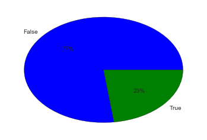

```python
plt.pie(Cabin_count['Survived'],labels = Cabin_count['Cabin'],autopct = '%0.0f%%')
```

8.0小结：从饼状图可以看出，有独立船舱的游客占总人数的23%，没有独立船舱的游客占总人数的77%，没有独立船舱的游客占大多数。

# 8.1：游客是否有独立的船舱与生还率的关系

```python
Cabin_Survived_mean = titanic_data_df.groupby('Cabin')['Survived'].mean()#把有独立船舱的游客分成一组，没有独立船舱的分为一组，求每一组的生存率。
Cabin_Passengers_count = titanic_data_df.groupby('Cabin')['Survived'].count()
```

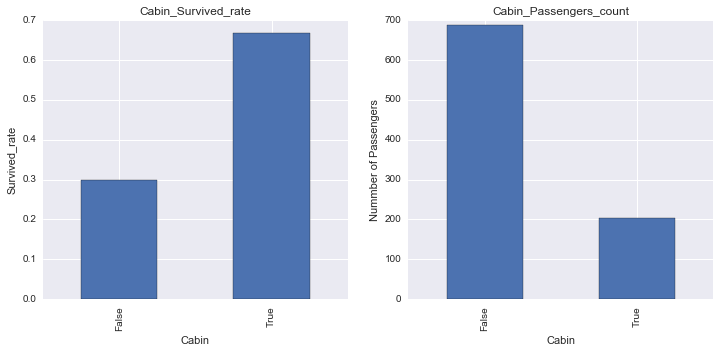

```python
f,(ax1,ax2) = plt.subplots(1,2)
f.set_size_inches(12,5)
Cabin_Survived_mean.plot(kind = 'bar',ax = ax1)
Cabin_Passengers_count.plot(kind = 'bar',ax = ax2)
ax1.set_title('Cabin_Survived_rate')
ax1.set_ylabel('Survived_rate')
ax2.set_title('Cabin_Passengers_count')
ax2.set_ylabel('Nummber of Passengers')
```

8.1.小结：从柱状图可以看出，有独立船舱的游客，生还率要比没有独立船舱的游客生还率高的多。

8推论：独立船舱的游客生还率更高可能是因为独立船舱有充足的救生设备，而且当危险发生时，独立船舱的游客一般不会发生拥挤，更容易拿到属于自己的救生设备，因此更容易获救。

8推论的不足之处（备注）：由于在数据处理的时候，采取的是把数据缺失处全部填充为False，把False处默认为该游客没有独立船舱，但是真实情况可能会有所不同，也有可能被标记为False的游客，大部分有自己的独立船舱，仅仅是因为数据丢失了而已，因此，推论四在这种情况下就不再成立了。所以8推论的结论有待进一步商榷，仅供参考和推测可能的原因。

# 9.0：有不同数量同船的兄弟姐妹的游客的人口分布

```python
SibSp_count = titanic_data_df.groupby('SibSp',as_index = False)['Survived'].count()
SibSp_count#有不同兄弟姐妹人数的游客的人口分布统计表。
```

|  | SibSp | Survived |
| --- | --- | --- |
| 0 | 0 | 608 |
| 1 | 1 | 209 |
| 2 | 2 | 28 |
| 3 | 3 | 16 |
| 4 | 4 | 18 |
| 5 | 5 | 5 |
| 6 | 8 | 7 |

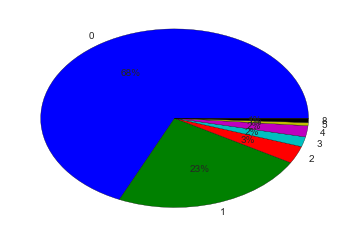

```python
plt.pie(SibSp_count['Survived'],labels = SibSp_count['SibSp'],autopct = '%0.0f%%')
```

9.0小结：从饼状图可以看出，没有兄弟姐妹同船的游客占总人数的68%，有一个兄弟或者姐妹同船的游客占总人数的23%，其余5种情况占9%比例。

# 9.1：有不同数量兄弟或者姐妹同船的游客与生还率的关系

```python
SibSp_Survived_mean = titanic_data_df.groupby('SibSp')['Survived'].mean()
SibSp_Passengers_count = titanic_data_df.groupby('SibSp')['Survived'].count()
SibSp_Survived_mean#有不同兄弟姐妹人数的游客生还率统计表。
```

```
SibSp
0    0.345395
1    0.535885
2    0.464286
3    0.250000
4    0.166667
5    0.000000
8    0.000000
Name: Survived, dtype: float64
```

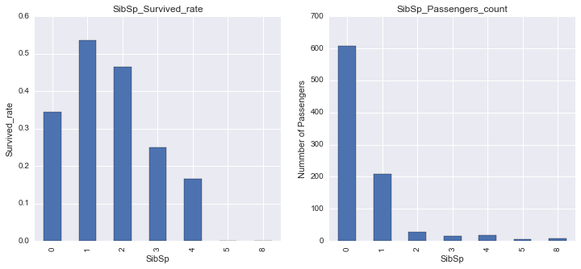

```python
f,(ax1,ax2) = plt.subplots(1,2)
f.set_size_inches(12,5)
SibSp_Survived_mean.plot(kind = 'bar',ax = ax1)
SibSp_Passengers_count.plot(kind = 'bar',ax = ax2)
ax1.set_title('SibSp_Survived_rate')
ax1.set_ylabel('Survived_rate')
ax2.set_title('SibSp_Passengers_count')
ax2.set_ylabel('Nummber of Passengers')
```

# 9.2：有不同数量父母或者孩子同船的游客的人口分布

```python
Parch_count = titanic_data_df.groupby('Parch',as_index = False)['Survived'].count()
Parch_count#有同船父母或孩子的游客的人口分布统计表。
```

|  | Parch | Survived |
| --- | --- | --- |
| 0 | 0 | 678 |
| 1 | 1 | 118 |
| 2 | 2 | 80 |
| 3 | 3 | 5 |
| 4 | 4 | 4 |
| 5 | 5 | 5 |
| 6 | 6 | 1 |

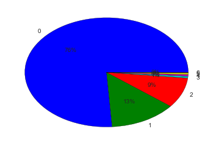

```python
plt.pie(Parch_count['Survived'],labels = Parch_count['Parch'],autopct = '%0.0f%%')
```

# 9.3：有不同数量同船父母或孩子的游客与生还率的关系

```python
Parch_Survived_mean = titanic_data_df.groupby('Parch')['Survived'].mean()
Parch_Passengers_count = titanic_data_df.groupby('Parch')['Survived'].count()
Parch_Survived_mean#有不同数量父母或者孩子人数的游客生还率统计表。
```

```
Parch
0    0.343658
1    0.550847
2    0.500000
3    0.600000
4    0.000000
5    0.200000
6    0.000000
Name: Survived, dtype: float64
```

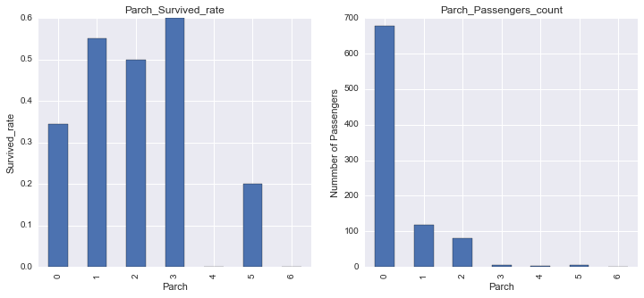

```python
f,(ax1,ax2) = plt.subplots(1,2)
f.set_size_inches(12,5)
Parch_Survived_mean.plot(kind = 'bar',ax = ax1)
Parch_Passengers_count.plot(kind = 'bar',ax = ax2)
ax1.set_title('Parch_Survived_rate')
ax1.set_ylabel('Survived_rate')
ax2.set_title('Parch_Passengers_count')
ax2.set_ylabel('Nummber of Passengers')
```

9.3小结：从柱状图可以看出，与游客同船的父母或者孩子人数为3人时，游客的生还率最高。

# 9.4：游客同船的兄弟姐妹人数和父母孩子人数与生还率的关系

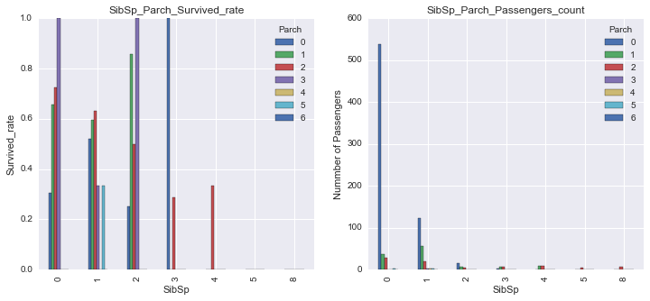

```python
SibSp_Parch_Survived_mean = titanic_data_df.groupby(['SibSp','Parch'])['Survived'].mean()
SibSp_Parch_Survived_count = titanic_data_df.groupby(['SibSp','Parch'])['Survived'].count()
f,(ax1,ax2) = plt.subplots(1,2)
f.set_size_inches(12,5)
SibSp_Parch_Survived_mean.unstack().plot(kind ='bar',ax = ax1)
SibSp_Parch_Survived_count.unstack().plot(kind = 'bar',ax = ax2)
ax1.set_title('SibSp_Parch_Survived_rate')
ax1.set_ylabel('Survived_rate')
ax2.set_title('SibSp_Parch_Passengers_count')
ax2.set_ylabel('Nummber of Passengers')
```

9推论二：当老人或者小孩的数量固定时，与游客随行的兄弟姐妹等青壮年越多，会逐渐在人群中失去弱势群体的身份，从而会失去更多获得额外帮助的机会和救生资源，使游客的生还率下降。

———————————————————————————————————————————————————————————————————————

# 结论：

第二部分：在相同等级的船舱中，游客普遍遵循女士优先，以及尊老爱幼的社会普世价值观，女性的生还率大于男性，孩子的生还率大于成年人，带老人的游客的生还率大于没有带老人的游客生还率。（此推论仅从数据可视化图表中直观看到，并未进行相关性验证，因此结论只是暂时的，有待进一步验证。）

第三部分：数据可视化显示有独立船舱的游客，生还率明显高于没有独立船舱的游客，原因可能是独立船舱内有更充足的救生设备，遇到危险时，没有人员的拥挤，更容易拿到救生设备，因此独立船舱的游客生还率更高。（1.此推论仅从数据可视化图表中直观看到，并未进行相关性验证，因此结论只是暂时的，有待进一步验证。2.此推论的假设前提是：['Cabin']列大部分数据缺失的部分本来就是没有独立船舱的，如果假设不成立，则此推论不成立，因此第三部分的推论仅供参考。）